# Introduction to raster data in R

This activity will introduce you to working with raster data in R.

**R Skill Level:** Intermediate - this activity assumes you have a working knowledge of `R`

# Objectives & Goals

**Upon completion of this activity, you will:**

- know how to **create** and write rasters
- know how to **plot** rasters & customize legends
- know how to do raster **calculations**
- Be able to **project** rasters
- Be able to **extract values** from rasters
- Be able reclassify / resampling rasters

### Required packages

To complete the following activity you will need the following packages installed:

**raster**  
**sp**  
**rgeos**

#### Installing the packages

If installing these packages for the first time consider adding `dependencies=TRUE`  
`install.packages(“raster”)`  
`install.packages(“sp”)`  
`install.packages(“rgeos”)`

# What is a raster?

A raster is a spatially explicit matrix or `grid` where each cell represents a geographic location. Each cell represents a pixel on a surface. The size of each pixel defines the resolution or `res` of raster. The smaller the pixel size the finer the spatial resolution. The `extent` or spatial coverage of a raster is defined by the minima and maxima for both x and y coordinates.

Rasters can be created from the following data classes:

Numeric

Integer

Categorical

## Raster formats

# Creating & writing rasters

## Raster data in R

Let’s begin by creating a raster from scratch. We’ll use the `raster` package to make an empty raster, set the `extent` and resolution (`res`) and assign values. Once we create a raster in R - we’ll take a closer look at the metadata and structure of rasters in `R`.

load the `raster` package if you haven’t already done so. If you need to install the `raster` package - see how to do that here

```r
# load library
library(raster)
```

Now that the `raster` library is loaded we can use the `raster()` function to create a raster in `R`.

```r
# Create a raster from scratch using raster
firstRaster <- raster(xmn = -100,   # set minimum x coordinate
                      xmx = -60,    # set maximum x coordinate
                      ymn = 25,     # set minimum y coordinate
                      ymx = 50,     # set maximum y coordinate
                      res = c(1,1)) # resolution in c(x,y) direction
```

Here is what that raster looks like in `R`

```r
# Take a look at what the raster looks like
firstRaster
```

```
## class       : RasterLayer
## dimensions  : 25, 40, 1000  (nrow, ncol, ncell)
## resolution  : 1, 1  (x, y)
## extent      : -100, -60, 25, 50  (xmin, xmax, ymin, ymax)
## coord. ref. : +proj=longlat +datum=WGS84 +ellps=WGS84 +towgs84=0,0,0
```

Notice that the object is of `class: RasterLayer` has 25 rows, 40 columns and 1000 cells. The resolution (`res`) is 1x1 degree. The raster’s `extent` ranges from -100 to -60 degrees longitude and 25 to 50 degrees latitude. The coordinate reference is WGS84 by default because `raster` recognized our inputs as degrees longitude/latitude. It doesn’t always do so.

### Setting raster values

Currently there are no values associated with the raster layer we just created. It’s empty. We can assign values to the raster in a few ways. We’ll set the values of the raster using the `[]` convention. See the `setValues` function in the `raster` package for another way to set values of a raster. We’ll sequence values from 1 to the number of cells within the raster. You can extract the number of cells within a raster using the `ncell` function.  
*note - the number of values you supply needs to be equivilant to the number of cells in the raster. You can however provide `NA` values.*

```r
# Assign values to raster
firstRaster[] <- seq(from = 1, to = ncell(firstRaster),by = 1)

# Take a look at the raster now
firstRaster
```

```
## class       : RasterLayer
## dimensions  : 25, 40, 1000  (nrow, ncol, ncell)
## resolution  : 1, 1  (x, y)
## extent      : -100, -60, 25, 50  (xmin, xmax, ymin, ymax)
## coord. ref. : +proj=longlat +datum=WGS84 +ellps=WGS84 +towgs84=0,0,0
## data source : in memory
## names       : layer
## values      : 1, 1000  (min, max)
```

You should now notice there are a few new attributes to our raster object. We gained `data source:`, `names` and `values` fields. The `data source` attribute tells us that the raster information is stored in our memory. The `names` field gave a name to the `values` we provided. The `values` we supplied are now contained in the `values` field.

Now that the raster has values we can do a few things - like plot the raster.

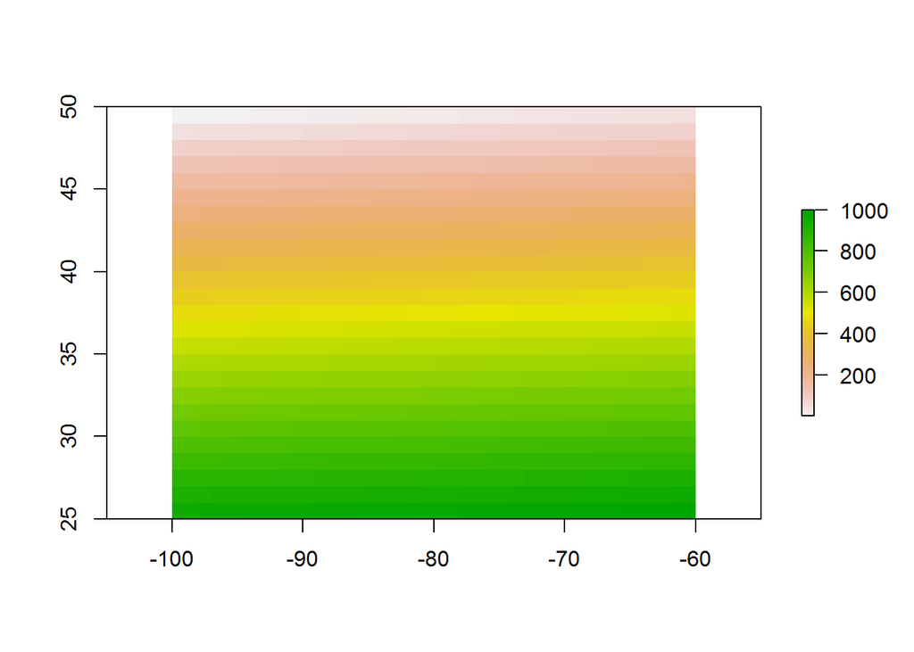

```r
plot(firstRaster)
```

back to start